# Analyzing Movie Reviews

## Introduction

The dataset is stored in the `fandango_score_comparison.csv` file. It contains information on how major movie review services rated movies. The data originally came from [FiveThirtyEight](http://fivethirtyeight.com/features/fandango-movies-ratings/).

Each row represents a single movie. Each column contains information about how the online moview review services RottenTomatoes, Metacritic, IMDB, and Fandango rated the movie. The dataset was put together to help detect bias in the movie review sites. Each of these sites has 2 types of score -- User scores, which aggregate user reviews, and Critic score, which aggregate professional critical reviews of the movie.

```python
import pandas as pd
movies = pd.read_csv("fandango_score_comparison.csv")
movies
```

|  | FILM | RottenTomatoes | RottenTomatoes_User | Metacritic | Metacritic_User | IMDB | Fandango_Stars | Fandango_Ratingvalue | RT_norm | RT_user_norm | ... | IMDB_norm | RT_norm_round | RT_user_norm_round | Metacritic_norm_round | Metacritic_user_norm_round | IMDB_norm_round | Metacritic_user_vote_count | IMDB_user_vote_count | Fandango_votes | Fandango_Difference |
| --- | --- | --- | --- | --- | --- | --- | --- | --- | --- | --- | --- | --- | --- | --- | --- | --- | --- | --- | --- | --- | --- |
| 0 | Avengers: Age of Ultron (2015) | 74 | 86 | 66 | 7.1 | 7.8 | 5.0 | 4.5 | 3.70 | 4.30 | ... | 3.90 | 3.5 | 4.5 | 3.5 | 3.5 | 4.0 | 1330 | 271107 | 14846 | 0.5 |
| 1 | Cinderella (2015) | 85 | 80 | 67 | 7.5 | 7.1 | 5.0 | 4.5 | 4.25 | 4.00 | ... | 3.55 | 4.5 | 4.0 | 3.5 | 4.0 | 3.5 | 249 | 65709 | 12640 | 0.5 |
| 2 | Ant-Man (2015) | 80 | 90 | 64 | 8.1 | 7.8 | 5.0 | 4.5 | 4.00 | 4.50 | ... | 3.90 | 4.0 | 4.5 | 3.0 | 4.0 | 4.0 | 627 | 103660 | 12055 | 0.5 |
| 3 | Do You Believe? (2015) | 18 | 84 | 22 | 4.7 | 5.4 | 5.0 | 4.5 | 0.90 | 4.20 | ... | 2.70 | 1.0 | 4.0 | 1.0 | 2.5 | 2.5 | 31 | 3136 | 1793 | 0.5 |
| 4 | Hot Tub Time Machine 2 (2015) | 14 | 28 | 29 | 3.4 | 5.1 | 3.5 | 3.0 | 0.70 | 1.40 | ... | 2.55 | 0.5 | 1.5 | 1.5 | 1.5 | 2.5 | 88 | 19560 | 1021 | 0.5 |
| 5 | The Water Diviner (2015) | 63 | 62 | 50 | 6.8 | 7.2 | 4.5 | 4.0 | 3.15 | 3.10 | ... | 3.60 | 3.0 | 3.0 | 2.5 | 3.5 | 3.5 | 34 | 39373 | 397 | 0.5 |
| 6 | Irrational Man (2015) | 42 | 53 | 53 | 7.6 | 6.9 | 4.0 | 3.5 | 2.10 | 2.65 | ... | 3.45 | 2.0 | 2.5 | 2.5 | 4.0 | 3.5 | 17 | 2680 | 252 | 0.5 |
| 7 | Top Five (2014) | 86 | 64 | 81 | 6.8 | 6.5 | 4.0 | 3.5 | 4.30 | 3.20 | ... | 3.25 | 4.5 | 3.0 | 4.0 | 3.5 | 3.5 | 124 | 16876 | 3223 | 0.5 |
| 8 | Shaun the Sheep Movie (2015) | 99 | 82 | 81 | 8.8 | 7.4 | 4.5 | 4.0 | 4.95 | 4.10 | ... | 3.70 | 5.0 | 4.0 | 4.0 | 4.5 | 3.5 | 62 | 12227 | 896 | 0.5 |
| 9 | Love & Mercy (2015) | 89 | 87 | 80 | 8.5 | 7.8 | 4.5 | 4.0 | 4.45 | 4.35 | ... | 3.90 | 4.5 | 4.5 | 4.0 | 4.5 | 4.0 | 54 | 5367 | 864 | 0.5 |
| 10 | Far From The Madding Crowd (2015) | 84 | 77 | 71 | 7.5 | 7.2 | 4.5 | 4.0 | 4.20 | 3.85 | ... | 3.60 | 4.0 | 4.0 | 3.5 | 4.0 | 3.5 | 35 | 12129 | 804 | 0.5 |
| 11 | Black Sea (2015) | 82 | 60 | 62 | 6.6 | 6.4 | 4.0 | 3.5 | 4.10 | 3.00 | ... | 3.20 | 4.0 | 3.0 | 3.0 | 3.5 | 3.0 | 37 | 16547 | 218 | 0.5 |
| 12 | Leviathan (2014) | 99 | 79 | 92 | 7.2 | 7.7 | 4.0 | 3.5 | 4.95 | 3.95 | ... | 3.85 | 5.0 | 4.0 | 4.5 | 3.5 | 4.0 | 145 | 22521 | 64 | 0.5 |
| 13 | Unbroken (2014) | 51 | 70 | 59 | 6.5 | 7.2 | 4.5 | 4.1 | 2.55 | 3.50 | ... | 3.60 | 2.5 | 3.5 | 3.0 | 3.5 | 3.5 | 218 | 77518 | 9443 | 0.4 |
| 14 | The Imitation Game (2014) | 90 | 92 | 73 | 8.2 | 8.1 | 5.0 | 4.6 | 4.50 | 4.60 | ... | 4.05 | 4.5 | 4.5 | 3.5 | 4.0 | 4.0 | 566 | 334164 | 8055 | 0.4 |
| 15 | Taken 3 (2015) | 9 | 46 | 26 | 4.6 | 6.1 | 4.5 | 4.1 | 0.45 | 2.30 | ... | 3.05 | 0.5 | 2.5 | 1.5 | 2.5 | 3.0 | 240 | 104235 | 6757 | 0.4 |
| 16 | Ted 2 (2015) | 46 | 58 | 48 | 6.5 | 6.6 | 4.5 | 4.1 | 2.30 | 2.90 | ... | 3.30 | 2.5 | 3.0 | 2.5 | 3.5 | 3.5 | 197 | 49102 | 6437 | 0.4 |
| 17 | Southpaw (2015) | 59 | 80 | 57 | 8.2 | 7.8 | 5.0 | 4.6 | 2.95 | 4.00 | ... | 3.90 | 3.0 | 4.0 | 3.0 | 4.0 | 4.0 | 128 | 23561 | 5597 | 0.4 |
| 18 | Night at the Museum: Secret of the Tomb (2014) | 50 | 58 | 47 | 5.8 | 6.3 | 4.5 | 4.1 | 2.50 | 2.90 | ... | 3.15 | 2.5 | 3.0 | 2.5 | 3.0 | 3.0 | 103 | 50291 | 5445 | 0.4 |
| 19 | Pixels (2015) | 17 | 54 | 27 | 5.3 | 5.6 | 4.5 | 4.1 | 0.85 | 2.70 | ... | 2.80 | 1.0 | 2.5 | 1.5 | 2.5 | 3.0 | 246 | 19521 | 3886 | 0.4 |
| 20 | McFarland, USA (2015) | 79 | 89 | 60 | 7.2 | 7.5 | 5.0 | 4.6 | 3.95 | 4.45 | ... | 3.75 | 4.0 | 4.5 | 3.0 | 3.5 | 4.0 | 59 | 13769 | 3364 | 0.4 |
| 21 | Insidious: Chapter 3 (2015) | 59 | 56 | 52 | 6.9 | 6.3 | 4.5 | 4.1 | 2.95 | 2.80 | ... | 3.15 | 3.0 | 3.0 | 2.5 | 3.5 | 3.0 | 115 | 25134 | 3276 | 0.4 |
| 22 | The Man From U.N.C.L.E. (2015) | 68 | 80 | 55 | 7.9 | 7.6 | 4.5 | 4.1 | 3.40 | 4.00 | ... | 3.80 | 3.5 | 4.0 | 3.0 | 4.0 | 4.0 | 144 | 22104 | 2686 | 0.4 |
| 23 | Run All Night (2015) | 60 | 59 | 59 | 7.3 | 6.6 | 4.5 | 4.1 | 3.00 | 2.95 | ... | 3.30 | 3.0 | 3.0 | 3.0 | 3.5 | 3.5 | 141 | 50438 | 2066 | 0.4 |
| 24 | Trainwreck (2015) | 85 | 74 | 75 | 6.0 | 6.7 | 4.5 | 4.1 | 4.25 | 3.70 | ... | 3.35 | 4.5 | 3.5 | 4.0 | 3.0 | 3.5 | 169 | 27380 | 8381 | 0.4 |
| 25 | Selma (2014) | 99 | 86 | 89 | 7.1 | 7.5 | 5.0 | 4.6 | 4.95 | 4.30 | ... | 3.75 | 5.0 | 4.5 | 4.5 | 3.5 | 4.0 | 316 | 45344 | 7025 | 0.4 |
| 26 | Ex Machina (2015) | 92 | 86 | 78 | 7.9 | 7.7 | 4.5 | 4.1 | 4.60 | 4.30 | ... | 3.85 | 4.5 | 4.5 | 4.0 | 4.0 | 4.0 | 672 | 154499 | 3458 | 0.4 |
| 27 | Still Alice (2015) | 88 | 85 | 72 | 7.8 | 7.5 | 4.5 | 4.1 | 4.40 | 4.25 | ... | 3.75 | 4.5 | 4.5 | 3.5 | 4.0 | 4.0 | 153 | 57123 | 1258 | 0.4 |
| 28 | Wild Tales (2014) | 96 | 92 | 77 | 8.8 | 8.2 | 4.5 | 4.1 | 4.80 | 4.60 | ... | 4.10 | 5.0 | 4.5 | 4.0 | 4.5 | 4.0 | 107 | 50285 | 235 | 0.4 |
| 29 | The End of the Tour (2015) | 92 | 89 | 84 | 7.5 | 7.9 | 4.5 | 4.1 | 4.60 | 4.45 | ... | 3.95 | 4.5 | 4.5 | 4.0 | 4.0 | 4.0 | 19 | 1320 | 121 | 0.4 |
| ... | ... | ... | ... | ... | ... | ... | ... | ... | ... | ... | ... | ... | ... | ... | ... | ... | ... | ... | ... | ... | ... |
| 116 | Clouds of Sils Maria (2015) | 89 | 67 | 78 | 7.1 | 6.8 | 3.5 | 3.4 | 4.45 | 3.35 | ... | 3.40 | 4.5 | 3.5 | 4.0 | 3.5 | 3.5 | 36 | 11392 | 162 | 0.1 |
| 117 | Testament of Youth (2015) | 81 | 79 | 77 | 7.9 | 7.3 | 4.0 | 3.9 | 4.05 | 3.95 | ... | 3.65 | 4.0 | 4.0 | 4.0 | 4.0 | 3.5 | 15 | 5495 | 127 | 0.1 |
| 118 | Infinitely Polar Bear (2015) | 80 | 76 | 64 | 7.9 | 7.2 | 4.0 | 3.9 | 4.00 | 3.80 | ... | 3.60 | 4.0 | 4.0 | 3.0 | 4.0 | 3.5 | 8 | 1062 | 124 | 0.1 |
| 119 | Phoenix (2015) | 99 | 81 | 91 | 8.0 | 7.2 | 3.5 | 3.4 | 4.95 | 4.05 | ... | 3.60 | 5.0 | 4.0 | 4.5 | 4.0 | 3.5 | 21 | 3687 | 70 | 0.1 |
| 120 | The Wolfpack (2015) | 84 | 73 | 75 | 7.0 | 7.1 | 3.5 | 3.4 | 4.20 | 3.65 | ... | 3.55 | 4.0 | 3.5 | 4.0 | 3.5 | 3.5 | 8 | 1488 | 66 | 0.1 |
| 121 | The Stanford Prison Experiment (2015) | 84 | 87 | 68 | 8.5 | 7.1 | 4.0 | 3.9 | 4.20 | 4.35 | ... | 3.55 | 4.0 | 4.5 | 3.5 | 4.5 | 3.5 | 6 | 950 | 51 | 0.1 |
| 122 | Tangerine (2015) | 95 | 86 | 86 | 7.3 | 7.4 | 4.0 | 3.9 | 4.75 | 4.30 | ... | 3.70 | 5.0 | 4.5 | 4.5 | 3.5 | 3.5 | 14 | 696 | 36 | 0.1 |
| 123 | Magic Mike XXL (2015) | 62 | 64 | 60 | 5.4 | 6.3 | 4.5 | 4.4 | 3.10 | 3.20 | ... | 3.15 | 3.0 | 3.0 | 3.0 | 2.5 | 3.0 | 52 | 11937 | 9363 | 0.1 |
| 124 | Home (2015) | 45 | 65 | 55 | 7.3 | 6.7 | 4.5 | 4.4 | 2.25 | 3.25 | ... | 3.35 | 2.5 | 3.5 | 3.0 | 3.5 | 3.5 | 177 | 41158 | 7705 | 0.1 |
| 125 | The Wedding Ringer (2015) | 27 | 66 | 35 | 3.3 | 6.7 | 4.5 | 4.4 | 1.35 | 3.30 | ... | 3.35 | 1.5 | 3.5 | 2.0 | 1.5 | 3.5 | 126 | 37292 | 6506 | 0.1 |
| 126 | Woman in Gold (2015) | 52 | 81 | 51 | 7.2 | 7.4 | 4.5 | 4.4 | 2.60 | 4.05 | ... | 3.70 | 2.5 | 4.0 | 2.5 | 3.5 | 3.5 | 72 | 17957 | 2435 | 0.1 |
| 127 | The Last Five Years (2015) | 60 | 60 | 60 | 6.9 | 6.0 | 4.5 | 4.4 | 3.00 | 3.00 | ... | 3.00 | 3.0 | 3.0 | 3.0 | 3.5 | 3.0 | 20 | 4110 | 99 | 0.1 |
| 128 | Mission: Impossible â€“ Rogue Nation (2015) | 92 | 90 | 75 | 8.0 | 7.8 | 4.5 | 4.4 | 4.60 | 4.50 | ... | 3.90 | 4.5 | 4.5 | 4.0 | 4.0 | 4.0 | 362 | 82579 | 8357 | 0.1 |
| 129 | Amy (2015) | 97 | 91 | 85 | 8.8 | 8.0 | 4.5 | 4.4 | 4.85 | 4.55 | ... | 4.00 | 5.0 | 4.5 | 4.5 | 4.5 | 4.0 | 60 | 5630 | 729 | 0.1 |
| 130 | Jurassic World (2015) | 71 | 81 | 59 | 7.0 | 7.3 | 4.5 | 4.5 | 3.55 | 4.05 | ... | 3.65 | 3.5 | 4.0 | 3.0 | 3.5 | 3.5 | 1281 | 241807 | 34390 | 0.0 |
| 131 | Minions (2015) | 54 | 52 | 56 | 5.7 | 6.7 | 4.0 | 4.0 | 2.70 | 2.60 | ... | 3.35 | 2.5 | 2.5 | 3.0 | 3.0 | 3.5 | 204 | 55895 | 14998 | 0.0 |
| 132 | Max (2015) | 35 | 73 | 47 | 5.9 | 7.0 | 4.5 | 4.5 | 1.75 | 3.65 | ... | 3.50 | 2.0 | 3.5 | 2.5 | 3.0 | 3.5 | 15 | 5444 | 3412 | 0.0 |
| 133 | Paul Blart: Mall Cop 2 (2015) | 5 | 36 | 13 | 2.4 | 4.3 | 3.5 | 3.5 | 0.25 | 1.80 | ... | 2.15 | 0.5 | 2.0 | 0.5 | 1.0 | 2.0 | 211 | 15004 | 3054 | 0.0 |
| 134 | The Longest Ride (2015) | 31 | 73 | 33 | 4.8 | 7.2 | 4.5 | 4.5 | 1.55 | 3.65 | ... | 3.60 | 1.5 | 3.5 | 1.5 | 2.5 | 3.5 | 49 | 25214 | 2603 | 0.0 |
| 135 | The Lazarus Effect (2015) | 14 | 23 | 31 | 4.9 | 5.2 | 3.0 | 3.0 | 0.70 | 1.15 | ... | 2.60 | 0.5 | 1.0 | 1.5 | 2.5 | 2.5 | 62 | 17691 | 1651 | 0.0 |
| 136 | The Woman In Black 2 Angel of Death (2015) | 22 | 25 | 42 | 4.4 | 4.9 | 3.0 | 3.0 | 1.10 | 1.25 | ... | 2.45 | 1.0 | 1.5 | 2.0 | 2.0 | 2.5 | 55 | 14873 | 1333 | 0.0 |
| 137 | Danny Collins (2015) | 77 | 75 | 58 | 7.1 | 7.1 | 4.0 | 4.0 | 3.85 | 3.75 | ... | 3.55 | 4.0 | 4.0 | 3.0 | 3.5 | 3.5 | 33 | 11206 | 531 | 0.0 |
| 138 | Spare Parts (2015) | 52 | 83 | 50 | 7.1 | 7.2 | 4.5 | 4.5 | 2.60 | 4.15 | ... | 3.60 | 2.5 | 4.0 | 2.5 | 3.5 | 3.5 | 7 | 47377 | 450 | 0.0 |
| 139 | Serena (2015) | 18 | 25 | 36 | 5.3 | 5.4 | 3.0 | 3.0 | 0.90 | 1.25 | ... | 2.70 | 1.0 | 1.5 | 2.0 | 2.5 | 2.5 | 19 | 12165 | 50 | 0.0 |
| 140 | Inside Out (2015) | 98 | 90 | 94 | 8.9 | 8.6 | 4.5 | 4.5 | 4.90 | 4.50 | ... | 4.30 | 5.0 | 4.5 | 4.5 | 4.5 | 4.5 | 807 | 96252 | 15749 | 0.0 |
| 141 | Mr. Holmes (2015) | 87 | 78 | 67 | 7.9 | 7.4 | 4.0 | 4.0 | 4.35 | 3.90 | ... | 3.70 | 4.5 | 4.0 | 3.5 | 4.0 | 3.5 | 33 | 7367 | 1348 | 0.0 |
| 142 | '71 (2015) | 97 | 82 | 83 | 7.5 | 7.2 | 3.5 | 3.5 | 4.85 | 4.10 | ... | 3.60 | 5.0 | 4.0 | 4.0 | 4.0 | 3.5 | 60 | 24116 | 192 | 0.0 |
| 143 | Two Days, One Night (2014) | 97 | 78 | 89 | 8.8 | 7.4 | 3.5 | 3.5 | 4.85 | 3.90 | ... | 3.70 | 5.0 | 4.0 | 4.5 | 4.5 | 3.5 | 123 | 24345 | 118 | 0.0 |
| 144 | Gett: The Trial of Viviane Amsalem (2015) | 100 | 81 | 90 | 7.3 | 7.8 | 3.5 | 3.5 | 5.00 | 4.05 | ... | 3.90 | 5.0 | 4.0 | 4.5 | 3.5 | 4.0 | 19 | 1955 | 59 | 0.0 |
| 145 | Kumiko, The Treasure Hunter (2015) | 87 | 63 | 68 | 6.4 | 6.7 | 3.5 | 3.5 | 4.35 | 3.15 | ... | 3.35 | 4.5 | 3.0 | 3.5 | 3.0 | 3.5 | 19 | 5289 | 41 | 0.0 |

146 rows × 22 columns

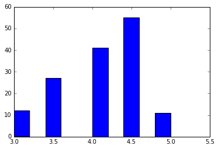

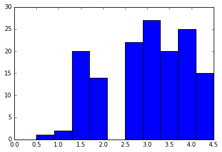

```python
import matplotlib.pyplot as plt
%matplotlib inline
plt.hist(movies["Fandango_Stars"])
plt.show()
plt.hist(movies["Metacritic_norm_round"])
plt.show()
```

It seems that all movies get high scores in Fandango.

```python
import numpy as np
Fmean = movies["Fandango_Stars"].mean()
Mmean = movies["Metacritic_norm_round"].mean()
Fmedian = movies["Fandango_Stars"].median()
Mmedian = movies["Metacritic_norm_round"].median()
Fstd = np.std(movies["Fandango_Stars"])
Mstd = np.std(movies["Metacritic_norm_round"])
print(Fmean)
print(Mmean)
print(Fmedian)
print(Mmedian)
print(Fstd)
print(Mstd)
```

```
4.08904109589
2.97260273973
4.0
3.0
0.53853216127
0.987561029704
```

Note that in Fandango the mean of movie's scores is higher than the median. On the contrary, Metacritic gets higher median. This shows that there are more movies get high score in Fandango.

Another thing worth to discuss is that scores of movies in Fandango have much higher mean and smaller standard deviation. That is because all of the movies have a high score (>=3.0) and inflated in Fandango.

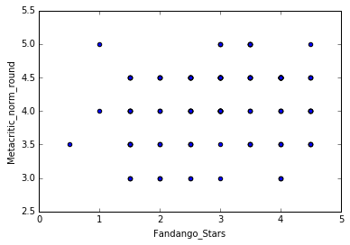

```python
plt.scatter(y = movies["Fandango_Stars"],x = movies["Metacritic_norm_round"])
plt.ylabel("Metacritic_norm_round")
plt.xlabel("Fandango_Stars")
```

```python
movies["fm_diff"] = abs(movies["Metacritic_norm_round"] - movies["Fandango_Stars"])
movies.sort_values(by="fm_diff", ascending = False).head(5)
```

|  | FILM | RottenTomatoes | RottenTomatoes_User | Metacritic | Metacritic_User | IMDB | Fandango_Stars | Fandango_Ratingvalue | RT_norm | RT_user_norm | ... | RT_norm_round | RT_user_norm_round | Metacritic_norm_round | Metacritic_user_norm_round | IMDB_norm_round | Metacritic_user_vote_count | IMDB_user_vote_count | Fandango_votes | Fandango_Difference | fm_diff |
| --- | --- | --- | --- | --- | --- | --- | --- | --- | --- | --- | --- | --- | --- | --- | --- | --- | --- | --- | --- | --- | --- |
| 3 | Do You Believe? (2015) | 18 | 84 | 22 | 4.7 | 5.4 | 5.0 | 4.5 | 0.90 | 4.20 | ... | 1.0 | 4.0 | 1.0 | 2.5 | 2.5 | 31 | 3136 | 1793 | 0.5 | 4.0 |
| 85 | Little Boy (2015) | 20 | 81 | 30 | 5.9 | 7.4 | 4.5 | 4.3 | 1.00 | 4.05 | ... | 1.0 | 4.0 | 1.5 | 3.0 | 3.5 | 38 | 5927 | 811 | 0.2 | 3.0 |
| 47 | Annie (2014) | 27 | 61 | 33 | 4.8 | 5.2 | 4.5 | 4.2 | 1.35 | 3.05 | ... | 1.5 | 3.0 | 1.5 | 2.5 | 2.5 | 108 | 19222 | 6835 | 0.3 | 3.0 |
| 19 | Pixels (2015) | 17 | 54 | 27 | 5.3 | 5.6 | 4.5 | 4.1 | 0.85 | 2.70 | ... | 1.0 | 2.5 | 1.5 | 2.5 | 3.0 | 246 | 19521 | 3886 | 0.4 | 3.0 |
| 134 | The Longest Ride (2015) | 31 | 73 | 33 | 4.8 | 7.2 | 4.5 | 4.5 | 1.55 | 3.65 | ... | 1.5 | 3.5 | 1.5 | 2.5 | 3.5 | 49 | 25214 | 2603 | 0.0 | 3.0 |

5 rows × 23 columns

```python
import scipy.stats
r,p = scipy.stats.pearsonr(movies["Fandango_Stars"],movies["Metacritic_norm_round"])
r
```

```
0.17844919073895918
```

## Fandango and Metacritic correlation

The low correlation between Fandango and Metacritic scores indicates that Fandango scores aren't just inflated, they are fundamentally different. For whatever reason, it appears like Fandango both inflates scores overall, and inflates scores differently depending on the movie.

```python
slope, intercept, r_value, p_value, std_err= scipy.stats.linregress(y = movies["Fandango_Stars"],x = movies["Metacritic_norm_round"])
pred_3 = 3 * slope + intercept
pred_3
```

```
4.0917071528212041
```

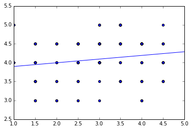

```python
pred_1 = 1 * slope + intercept
pred_5 = 5 * slope + intercept
plt.scatter(movies["Metacritic_norm_round"], movies["Fandango_Stars"])
plt.plot([1,5],[pred_1,pred_5])
plt.xlim(1,5)
plt.show()
```